# Об алгоритмах подробнее

```r
library(ggplot2)
library(dplyr)
library(caret)
```

### Данные (рак предстательной железы)

Загружаем данные

```r
prCancer <- read.csv("~/shared/minor3_2017/3-SecondYear-ML/practice-4-class-imbalanced/Prostate_Cancer.csv")
```

Посмотрим на них

```r
str(prCancer)
```

```
## 'data.frame':    100 obs. of  10 variables:
##  $ id               : int  1 2 3 4 5 6 7 8 9 10 ...
##  $ diagnosis_result : Factor w/ 2 levels "B","M": 2 1 2 2 2 1 2 2 2 2 ...
##  $ radius           : int  23 9 21 14 9 25 16 15 19 25 ...
##  $ texture          : int  12 13 27 16 19 25 26 18 24 11 ...
##  $ perimeter        : int  151 133 130 78 135 83 120 90 88 84 ...
##  $ area             : int  954 1326 1203 386 1297 477 1040 578 520 476 ...
##  $ smoothness       : num  0.143 0.143 0.125 0.07 0.141 0.128 0.095 0.119 0.127 0.119 ...
##  $ compactness      : num  0.278 0.079 0.16 0.284 0.133 0.17 0.109 0.165 0.193 0.24 ...
##  $ symmetry         : num  0.242 0.181 0.207 0.26 0.181 0.209 0.179 0.22 0.235 0.203 ...
##  $ fractal_dimension: num  0.079 0.057 0.06 0.097 0.059 0.076 0.057 0.075 0.074 0.082 ...
```

У нас есть 8 параметров, характеризующих новообразование:

- Radius
- Texture
- Perimeter
- Area
- Smoothness
- Compactness
- Symmetry
- Fractal dimension

Переменная `diagnosis_result`, соответствующая диагнозу, имеет два значения:

- В = Benign (доброкачественное новообразование)
- M = Malignant (злокачественное новообразование)

## Обучающая и тестовая выборки

```r
set.seed(345)
pc.test.ind = createDataPartition(prCancer$diagnosis_result, p = .7,
                                  list = FALSE,
                                  times = 1)
pc.test = prCancer[-pc.test.ind,]
pc.main = prCancer[pc.test.ind,]
```

Рассмотрим сначала всего два предиктора – периметр `perimeter` и коэффицент симметрии `symmetry`

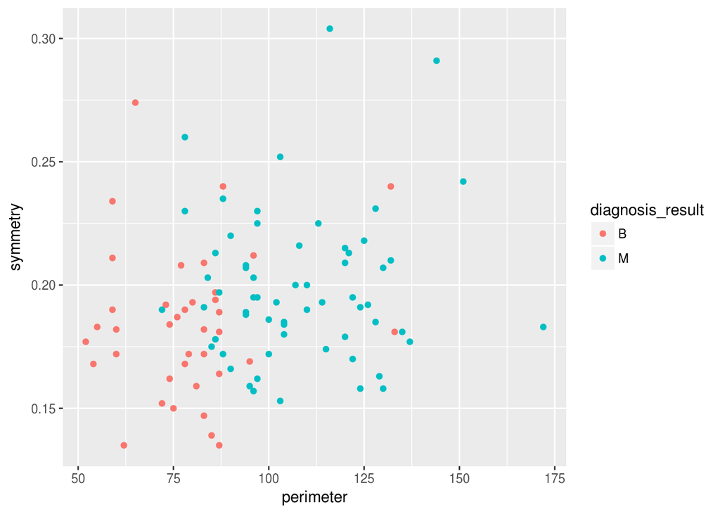

```r
ggplot(data = prCancer, aes(color = diagnosis_result)) + geom_point(aes(x=perimeter, y = symmetry))
```

```r
data.main <- dplyr::select(pc.main, diagnosis_result, perimeter, symmetry)
data.test <- dplyr::select(pc.test, diagnosis_result, perimeter, symmetry)
```

## Метод k ближайших соседей (k nearest neighbours)

Сначала рассмотрим общий принцип работы. Пусть у нас есть небольшой датасет с двумя классами элементов

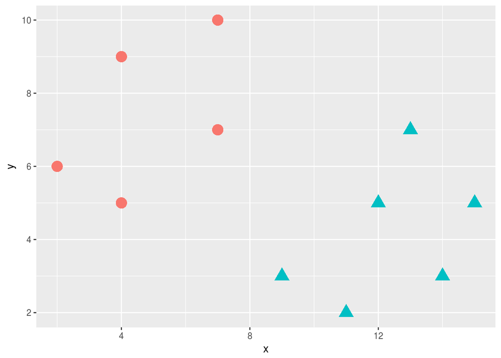

**1 ближайший сосед:** точка принадлежит к тому классу, что и ближайшая к ней точка. Ближайшая = расположенная на наименьшем расстоянии (расстояние чаще всего Евклидово, т.е. $\sqrt{(x_1-x_2)^2 + (y_1-y_2)^2}$).

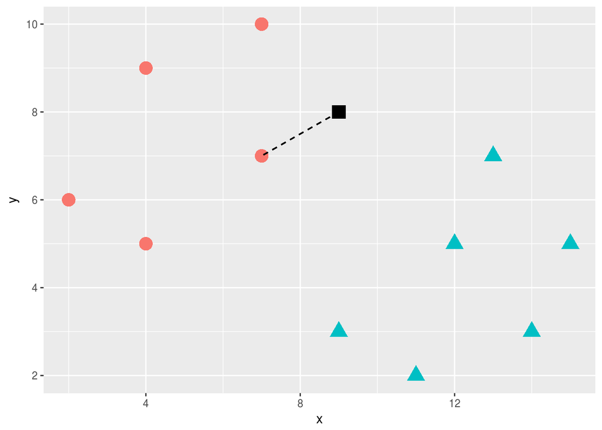

Итоговое разделение:

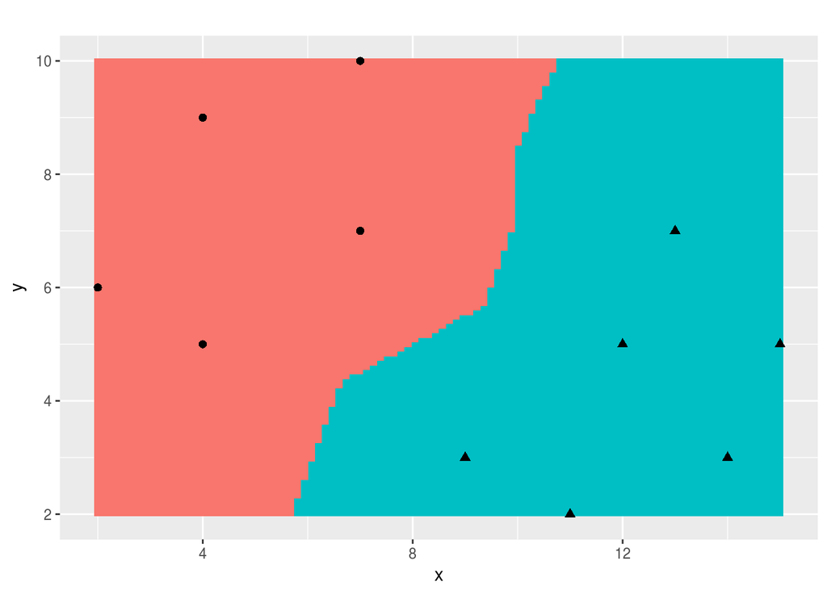

**k ближайших соседей:** точка принадлежит к тому классу, что и большинство из k ближайших к ней точек. Т.е. ищем k точек, расстояние до которых меньше, считаем долю каждого из классов среди этих точек и выбираем тот класс, доля которого больше. Например, для k = 3:

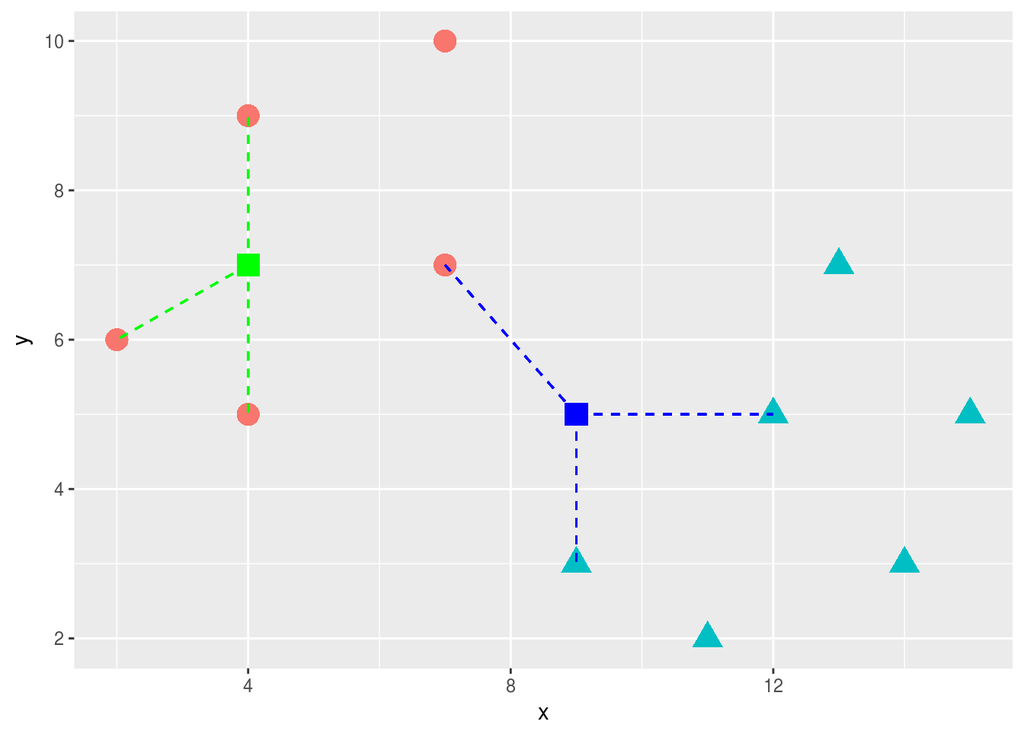

Для зеленой точки – из 3 ближайших соседей 3 красных и 0 голубых, значит относим к красным.

Для синей точки – из 3 ближайших соседей 1 красная и 2 голубых, значит относим к голубым.

Итоговое разделение:

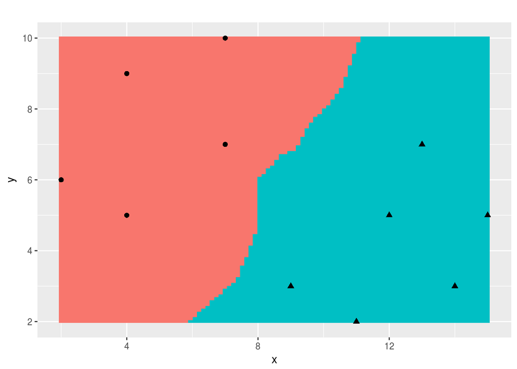

Что будет, если установить k = 11?

Как меняется результат при **увеличении k**? Рассмотрим на немного большем примере

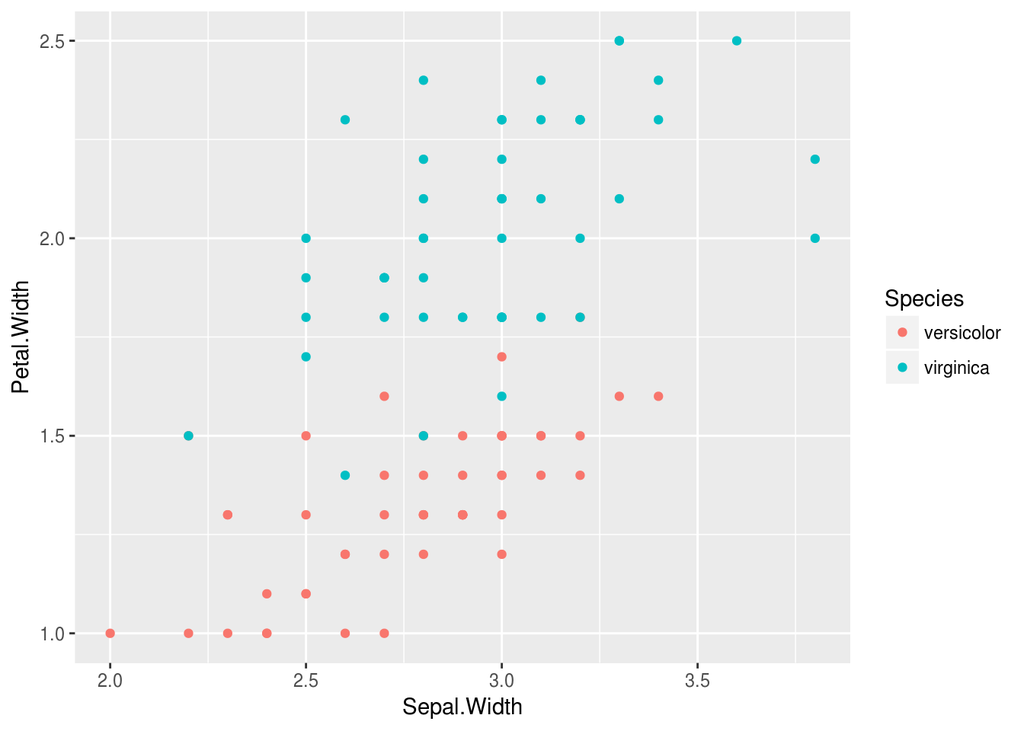

```r
iris <- filter(iris, Species != "setosa")
ggplot(data = iris) + geom_point(aes(x=Sepal.Width, y = Petal.Width, color = Species))
```

Для одного соседа:

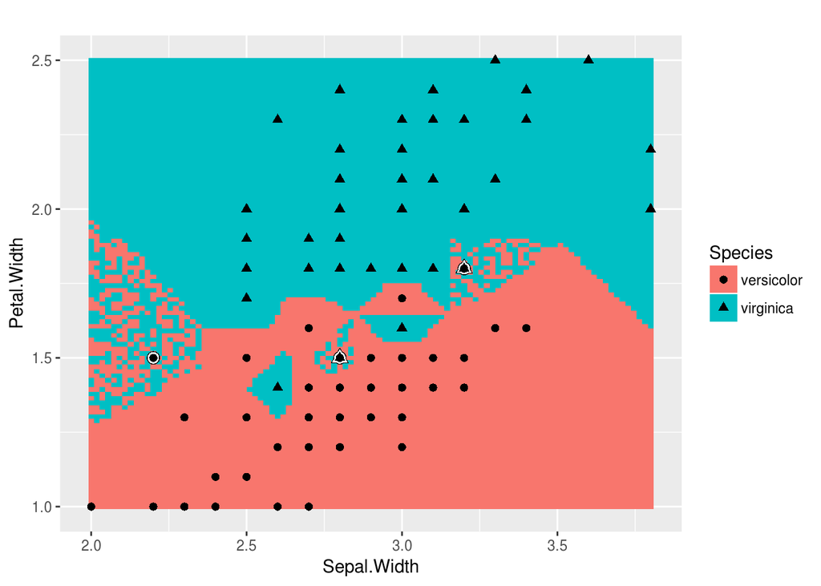

Для 3 соседей:

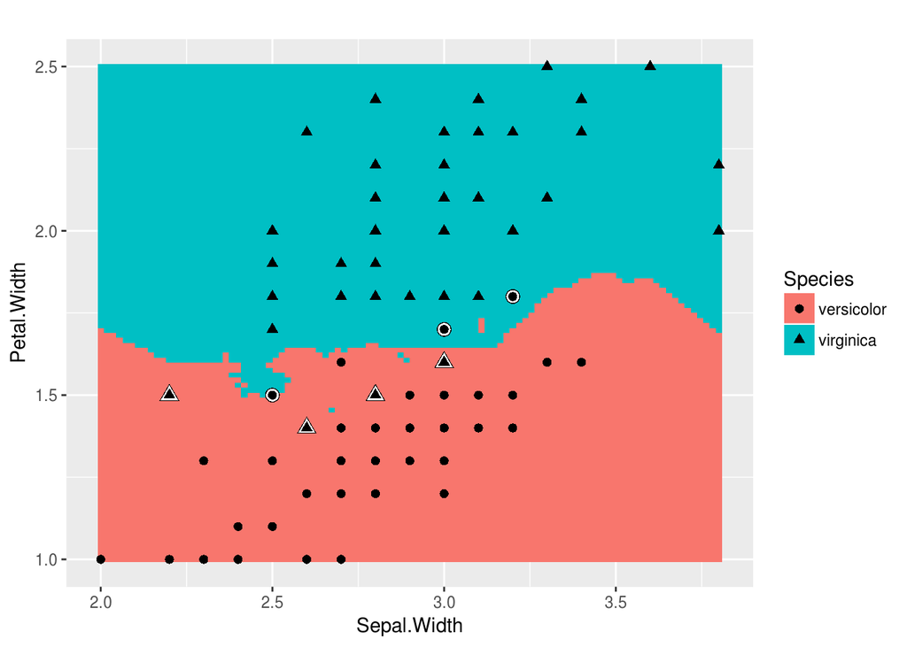

Для 5 соседей:

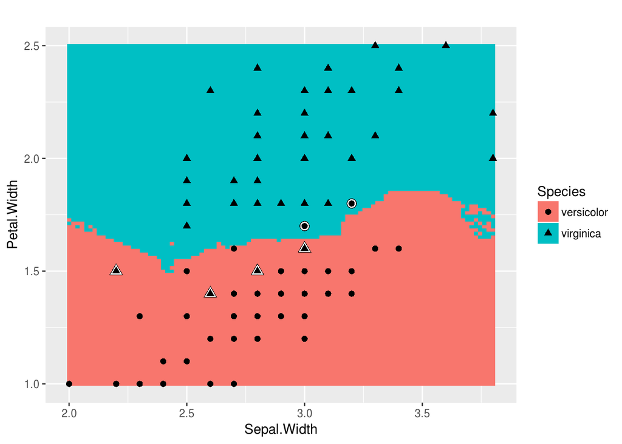

Для 10 соседей:

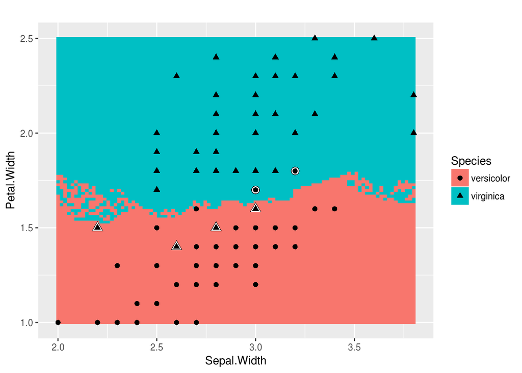

Для 25 соседей:

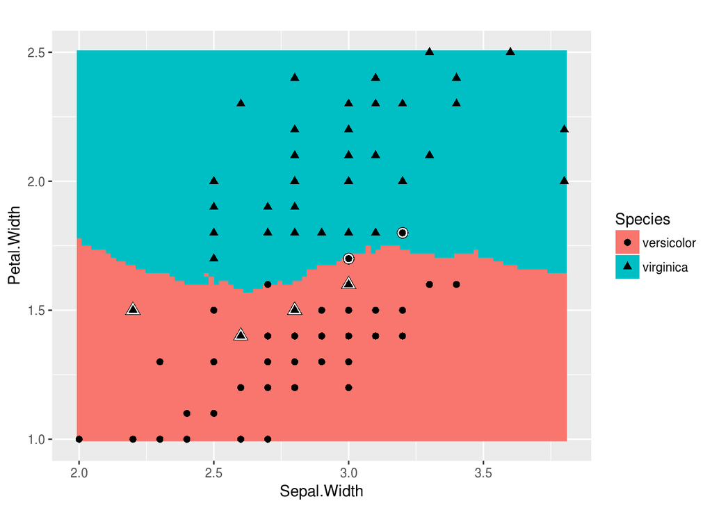

Чем больше k - тем более общую модель мы получаем. При небольших k разделение на классы больше “подогнано” к обучающим данным - при k = 1 точность на обучающей выборке равна 1 (ближайшая точка к любой точке – она сама), но на тестовой она уже существенно ниже. В целом зависимости можно представить следующим образом

Ошибка на обучающей выборке при изменении k

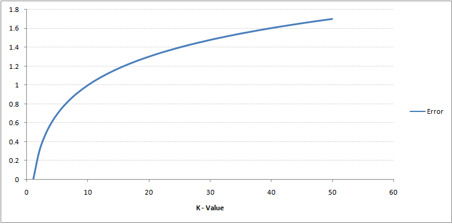

Ошибка на тестовой выборке при изменении k

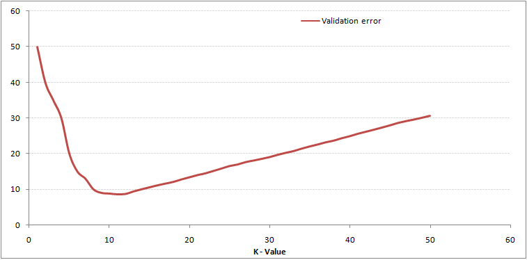

## Построение моделей

1 ближайший сосед

```r
library(class)
knn_model <- knn(train = dplyr::select(data.main, -diagnosis_result),
                 test = dplyr::select(data.test, -diagnosis_result),
                 cl=data.main$diagnosis_result)
```

Результаты на тестовой выборке

```r
confusionMatrix(knn_model, data.test$diagnosis_result)
```

```
## Confusion Matrix and Statistics
##
##           Reference
## Prediction  B  M
##          B  8  5
##          M  3 13
##
##                Accuracy : 0.7241
##                  95% CI : (0.5276, 0.8727)
##     No Information Rate : 0.6207
##     P-Value [Acc > NIR] : 0.1697
##
##                   Kappa : 0.4341
##  Mcnemar's Test P-Value : 0.7237
##
##             Sensitivity : 0.7273
##             Specificity : 0.7222
##          Pos Pred Value : 0.6154
##          Neg Pred Value : 0.8125
##              Prevalence : 0.3793
##          Detection Rate : 0.2759
##    Detection Prevalence : 0.4483
##       Balanced Accuracy : 0.7247
##
##        'Positive' Class : B
##
```

График

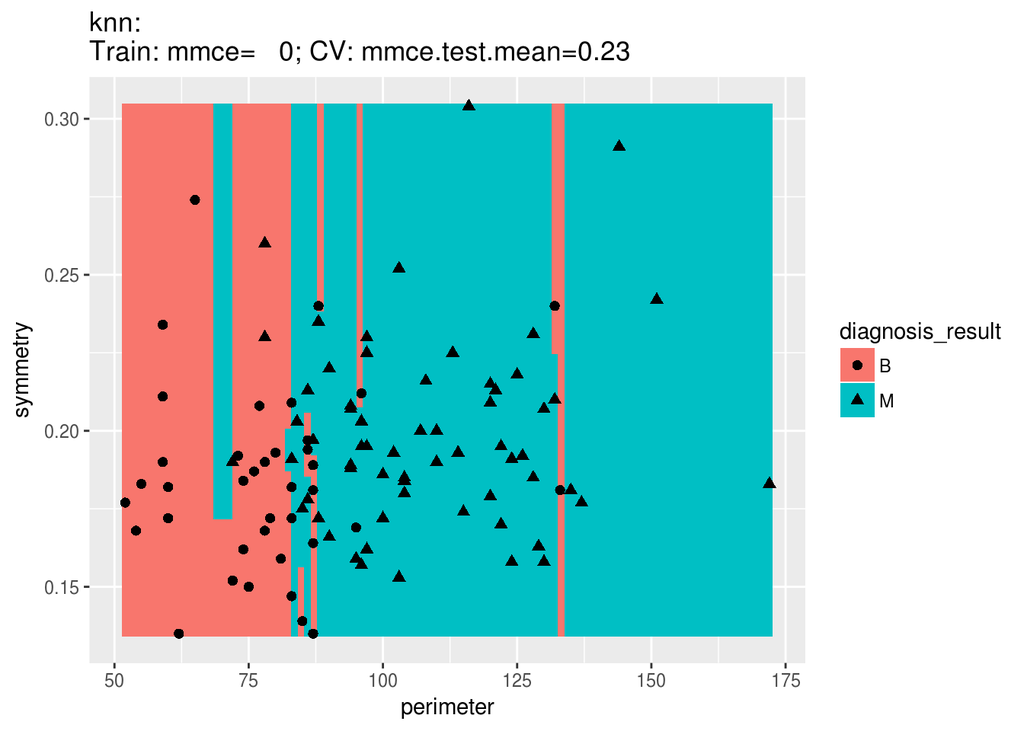

3 ближайших соседа

```r
knn_model <- knn(train = dplyr::select(data.main, -diagnosis_result),
                 test = dplyr::select(data.test, -diagnosis_result),
                 cl=data.main$diagnosis_result, k = 3)
```

Результаты на тестовой выборке

```r
confusionMatrix(knn_model,data.test$diagnosis_result)
```

```
## Confusion Matrix and Statistics
##
##           Reference
## Prediction  B  M
##          B  8  3
##          M  3 15
##
##                Accuracy : 0.7931
##                  95% CI : (0.6028, 0.9201)
##     No Information Rate : 0.6207
##     P-Value [Acc > NIR] : 0.03859
##
##                   Kappa : 0.5606
##  Mcnemar's Test P-Value : 1.00000
##
##             Sensitivity : 0.7273
##             Specificity : 0.8333
##          Pos Pred Value : 0.7273
##          Neg Pred Value : 0.8333
##              Prevalence : 0.3793
##          Detection Rate : 0.2759
##    Detection Prevalence : 0.3793
##       Balanced Accuracy : 0.7803
##
##        'Positive' Class : B
##
```

График

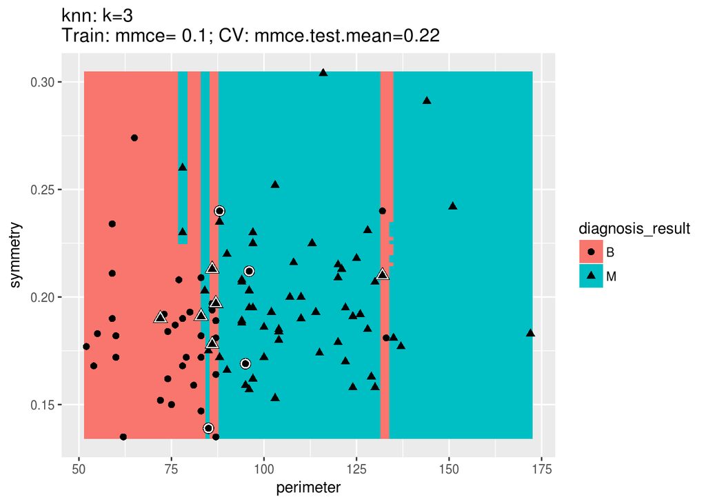

### Нормализация

**Обратите внимание:** используемые нами переменные имеют очень разные значения

```r
summary(prCancer$perimeter)
```

```
##    Min. 1st Qu.  Median    Mean 3rd Qu.    Max.
##   52.00   82.50   94.00   96.78  114.20  172.00
```

```r
summary(prCancer$symmetry)
```

```
##    Min. 1st Qu.  Median    Mean 3rd Qu.    Max.
##  0.1350  0.1720  0.1900  0.1932  0.2090  0.3040
```

Поэтому вклад в измерение расстояния у них очень разный: разница между самыми отдаленными значениями симметрии 0.169, а периметра – 120. Соответственно, для алгоритма при вычислении расстояния между точками периметр важнее (это видно и на графике – почти все разделение вертикальными линиями). Чтобы этого избежать, проводят нормализацию, т.е. приведение к единой шкале (традиционно к значениям от 0 до 1). Для этого нужно из каждой переменной вычесть ее минимальное значение и разделить на диапазон значений.

```r
smin <- min(prCancer$symmetry)
pmin <- min(prCancer$perimeter)
smax <- max(prCancer$symmetry)
pmax <- max(prCancer$perimeter)
prCancer$symmetry <-
  (prCancer$symmetry - smin)/(smax-smin)
prCancer$perimeter <-
  (prCancer$perimeter - pmin)/(pmax-pmin)
```

И не забыть повторить разделение на тестовую и обучающую выборки

```r
pc.test = prCancer[-pc.test.ind,]
pc.main = prCancer[pc.test.ind,]
```

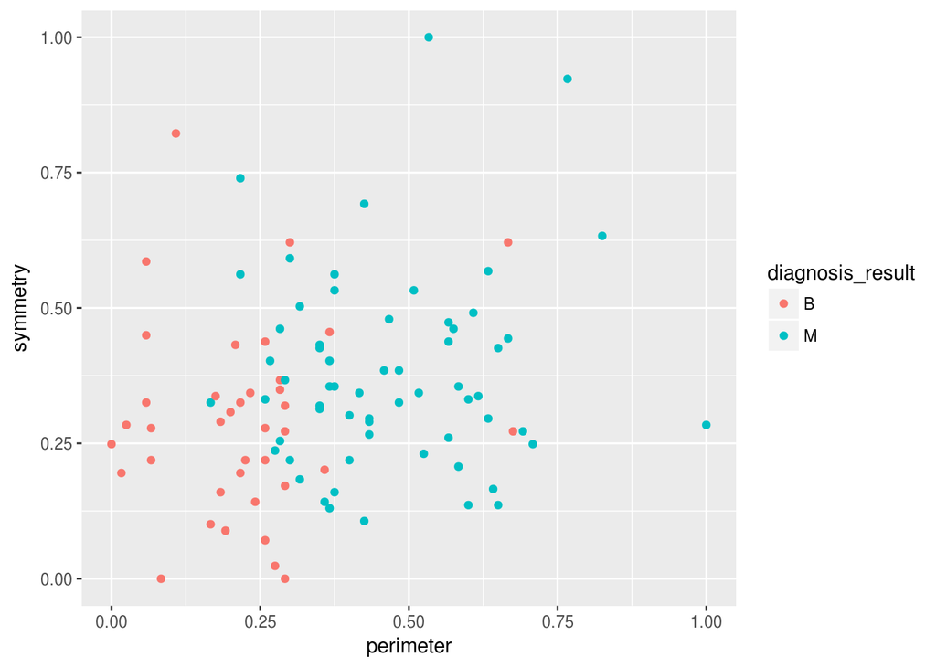

```r
ggplot(data = prCancer, aes(color = diagnosis_result)) + geom_point(aes(x=perimeter, y = symmetry))
```

```r
data.main <- dplyr::select(pc.main, diagnosis_result, perimeter, symmetry)
data.test <- dplyr::select(pc.test, diagnosis_result, perimeter, symmetry)
```

Новая модель

```r
knn_model <- knn(train = dplyr::select(data.main, -diagnosis_result),
                 test = dplyr::select(data.test, -diagnosis_result),
                 cl=data.main$diagnosis_result, k=3)
```

И новые результаты на тестовой выборке

```r
confusionMatrix(knn_model,data.test$diagnosis_result)
```

```
## Confusion Matrix and Statistics
##
##           Reference
## Prediction  B  M
##          B  8  2
##          M  3 16
##
##                Accuracy : 0.8276
##                  95% CI : (0.6423, 0.9415)
##     No Information Rate : 0.6207
##     P-Value [Acc > NIR] : 0.01422
##
##                   Kappa : 0.6272
##  Mcnemar's Test P-Value : 1.00000
##
##             Sensitivity : 0.7273
##             Specificity : 0.8889
##          Pos Pred Value : 0.8000
##          Neg Pred Value : 0.8421
##              Prevalence : 0.3793
##          Detection Rate : 0.2759
##    Detection Prevalence : 0.3448
##       Balanced Accuracy : 0.8081
##
##        'Positive' Class : B
##
```

График

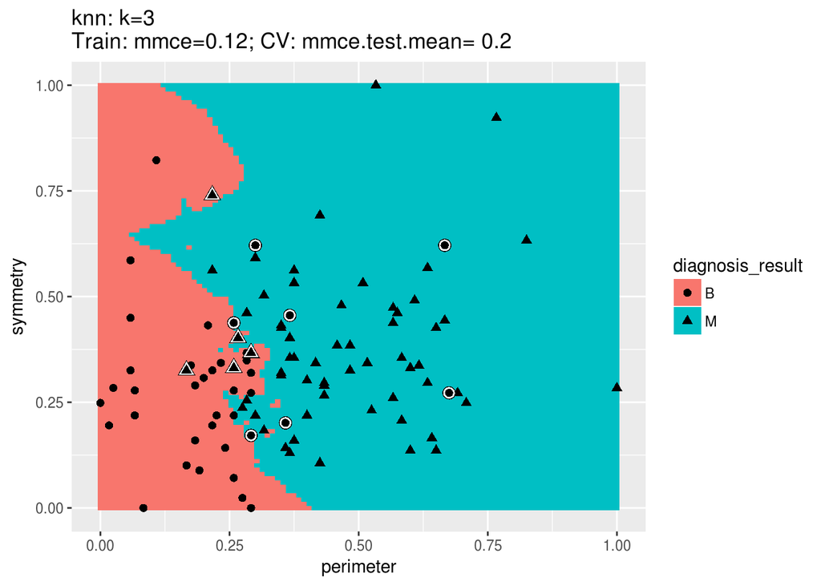

Результаты для другой реализации метода

```r
knn_model2 <- knn3(diagnosis_result~., data = data.main)
knn_pred <- predict(knn_model2, dplyr::select(data.test, -diagnosis_result), type = "class")
confusionMatrix(knn_pred, data.test$diagnosis_result)
```

```
## Confusion Matrix and Statistics
##
##           Reference
## Prediction  B  M
##          B  8  2
##          M  3 16
##
##                Accuracy : 0.8276
##                  95% CI : (0.6423, 0.9415)
##     No Information Rate : 0.6207
##     P-Value [Acc > NIR] : 0.01422
##
##                   Kappa : 0.6272
##  Mcnemar's Test P-Value : 1.00000
##
##             Sensitivity : 0.7273
##             Specificity : 0.8889
##          Pos Pred Value : 0.8000
##          Neg Pred Value : 0.8421
##              Prevalence : 0.3793
##          Detection Rate : 0.2759
##    Detection Prevalence : 0.3448
##       Balanced Accuracy : 0.8081
##
##        'Positive' Class : B
##
```

Для полной картины (и для удобного использования кросс-валидации, например) посмотрим, как такую модель можно построить с помощью функций пакета `caret`.

```r
data.m = data.main
knn_model3 <- caret::train(diagnosis_result ~ ., data=data.main, method = "knn")
knn_model3$finalModel
```

```
## 7-nearest neighbor classification model
## Training set class distribution:
##
##  B  M
## 27 44
```

```r
knn_pred <- predict(knn_model3, data.test)
confusionMatrix(knn_pred, data.test$diagnosis_result)
```

```
## Confusion Matrix and Statistics
##
##           Reference
## Prediction  B  M
##          B  8  1
##          M  3 17
##
##                Accuracy : 0.8621
##                  95% CI : (0.6834, 0.9611)
##     No Information Rate : 0.6207
##     P-Value [Acc > NIR] : 0.004251
##
##                   Kappa : 0.6963
##  Mcnemar's Test P-Value : 0.617075
##
##             Sensitivity : 0.7273
##             Specificity : 0.9444
##          Pos Pred Value : 0.8889
##          Neg Pred Value : 0.8500
##              Prevalence : 0.3793
##          Detection Rate : 0.2759
##    Detection Prevalence : 0.3103
##       Balanced Accuracy : 0.8359
##
##        'Positive' Class : B
##
```

```r
# вариант с автоматическим масштабированием -- удобно, когда много переменных
knn_model3 <- caret::train(diagnosis_result ~ ., data=data.main, method = "knn", preProcess = c("scale", "center"))
# !! внимание -- для новых данных нужно применять ту же нормализацию, что caret делает автоматически при использовании результата функции train
knn_pred <- predict(knn_model3, data.test)
```

**Ваша очередь**:

- Какой прозноз согласно модели будет при значениях периметра 80 и симметрии 0.22? (для модели knn3)
- Улучшится ли точность, если увеличить k? Какое значение k лучше выбрать?
- Улучшится ли точность, если добавить остальные предикторы?
- Сравните результаты при нормализации и без нее при включении всех предикторов

P.S.

```r
x <- data.frame(symmetry=(0.22-smin)/(smax-smin), perimeter=(80-pmin)/(pmax-pmin))
predict(knn_model2, x)
```

## Метод опорных векторов (Support Vector Machine)

Рассмотрим очень маленький пример: предсказание пола человека по его весу и росту (частично по [этим](http://www.svm-tutorial.com/2014/11/svm-understanding-math-part-1/) и [этим](http://www.algorithmist.ru/2011/07/support-vector-machines-with-examples.html) материалам)

Предлагаю собрать свой такой же датасет https://goo.gl/forms/S1jWAaOdQmANklfi2

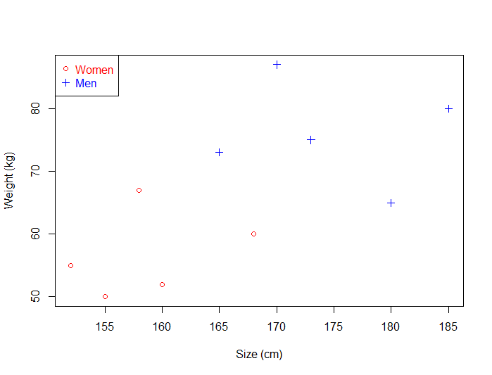

Можем разделить данные линией – все случаи, оказавшиеся ниже линии, будем относить к женщинам, выше – к мужчинам.

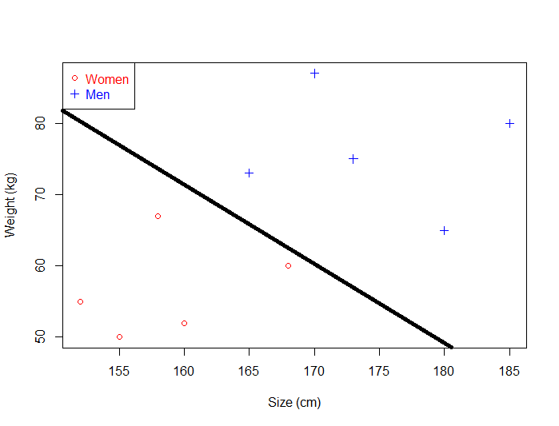

Но таких линий можно провести много:

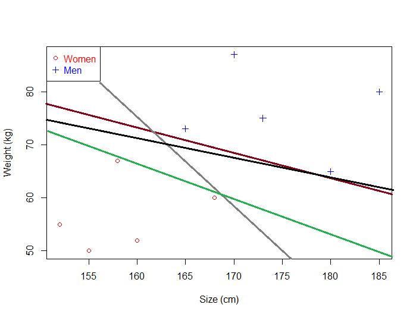

Как решить, какая лучше?

Если мы выбираем линию, которая лежит близко к одному из классов, то можем столкнуться с такой ситуацией для новых данных

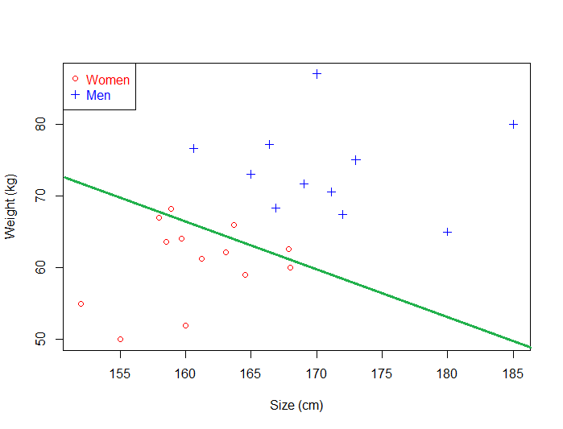

Т.е. нам нужна линия, которая максимально удалена от каждого из классов. Иными словами, линия, для которой расстояние между ней и ближайшими точками из каждого класса максимально.

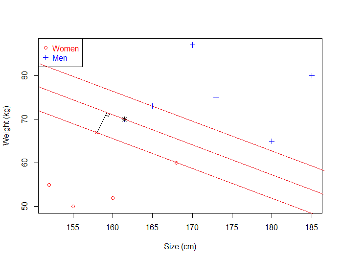

.

Эти ближайшие точки и называются **опорными векторами**. Такая линия одна и ее можно найти из системы уравнений.

Если у нас больше двух предикторов, принцип сохраняется, только делим мы классы не линией, а плоскостью (или гиперплоскостью).

Но что делать, если линейно мы разделить никак не можем? Например, в такой ситуации:

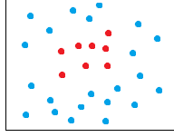

Тогда мы с помощью определенных функций преобразуем наши данные, “добавляем им размерность”, так, чтобы в новой форме данные можно было разделить линейно. Примерно так: [смотреть](https://www.youtube.com/watch?v=9NrALgHFwTo)

Такие функции делятся на классы – ядра (kernels), могут быть полиномиальными, радиальными, сигмоидными.

## Построение моделей

Используем нормализованный датасет

Как можно разделить классы? С каким ядром лучше?

### Метод опорных векторов с линейным ядром (Support Vector Machine with linear kernel)

```r
library("e1071")
svm_model <- svm(diagnosis_result ~ ., data=data.main, kernel="linear")
summary(svm_model)
```

```
##
## Call:
## svm(formula = diagnosis_result ~ ., data = data.main, kernel = "linear")
##
##
## Parameters:
##    SVM-Type:  C-classification
##  SVM-Kernel:  linear
##        cost:  1
##       gamma:  0.5
##
## Number of Support Vectors:  32
##
##  ( 16 16 )
##
##
## Number of Classes:  2
##
## Levels:
##  B M
```

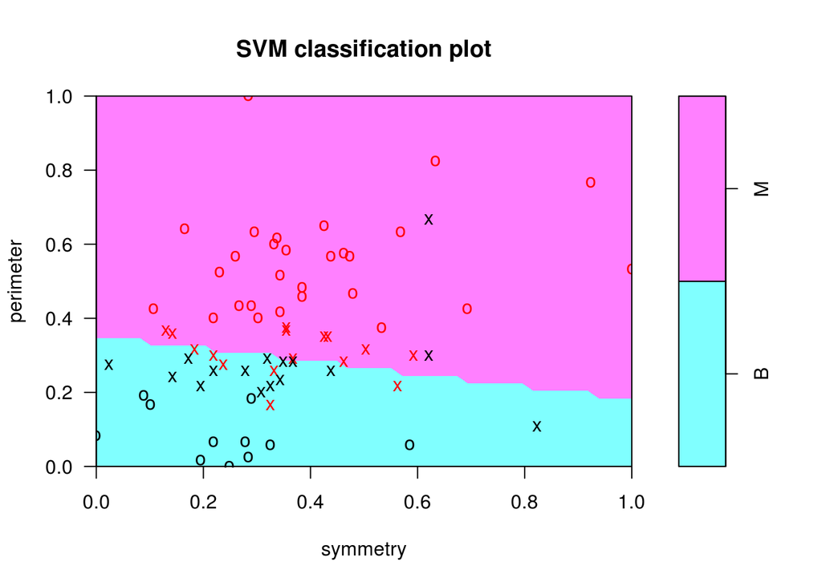

```r
plot(svm_model, data=data.main)
```

Результаты на обучающей

```r
svm.Pred<-predict(svm_model, data.main, probability=FALSE)
confusionMatrix(svm.Pred,data.main$diagnosis_result)
```

```
## Confusion Matrix and Statistics
##
##           Reference
## Prediction  B  M
##          B 22  5
##          M  5 39
##
##                Accuracy : 0.8592
##                  95% CI : (0.7562, 0.9303)
##     No Information Rate : 0.6197
##     P-Value [Acc > NIR] : 8.243e-06
##
##                   Kappa : 0.7012
##  Mcnemar's Test P-Value : 1
##
##             Sensitivity : 0.8148
##             Specificity : 0.8864
##          Pos Pred Value : 0.8148
##          Neg Pred Value : 0.8864
##              Prevalence : 0.3803
##          Detection Rate : 0.3099
##    Detection Prevalence : 0.3803
##       Balanced Accuracy : 0.8506
##
##        'Positive' Class : B
##
```

и тестовой выборках

```r
svm.Pred<-predict(svm_model, data.test, probability=FALSE)
confusionMatrix(svm.Pred,data.test$diagnosis_result)
```

```
## Confusion Matrix and Statistics
##
##           Reference
## Prediction  B  M
##          B  8  2
##          M  3 16
##
##                Accuracy : 0.8276
##                  95% CI : (0.6423, 0.9415)
##     No Information Rate : 0.6207
##     P-Value [Acc > NIR] : 0.01422
##
##                   Kappa : 0.6272
##  Mcnemar's Test P-Value : 1.00000
##
##             Sensitivity : 0.7273
##             Specificity : 0.8889
##          Pos Pred Value : 0.8000
##          Neg Pred Value : 0.8421
##              Prevalence : 0.3793
##          Detection Rate : 0.2759
##    Detection Prevalence : 0.3448
##       Balanced Accuracy : 0.8081
##
##        'Positive' Class : B
##
```

### Метод опорных векторов с полиномиальным ядром (Support Vector Machine with polynomial kernel)

```r
svm_model <- svm(diagnosis_result ~ ., data=data.main, kernel="polynomial")
summary(svm_model)
```

```
##
## Call:
## svm(formula = diagnosis_result ~ ., data = data.main, kernel = "polynomial")
##
##
## Parameters:
##    SVM-Type:  C-classification
##  SVM-Kernel:  polynomial
##        cost:  1
##      degree:  3
##       gamma:  0.5
##      coef.0:  0
##
## Number of Support Vectors:  39
##
##  ( 20 19 )
##
##
## Number of Classes:  2
##
## Levels:
##  B M
```

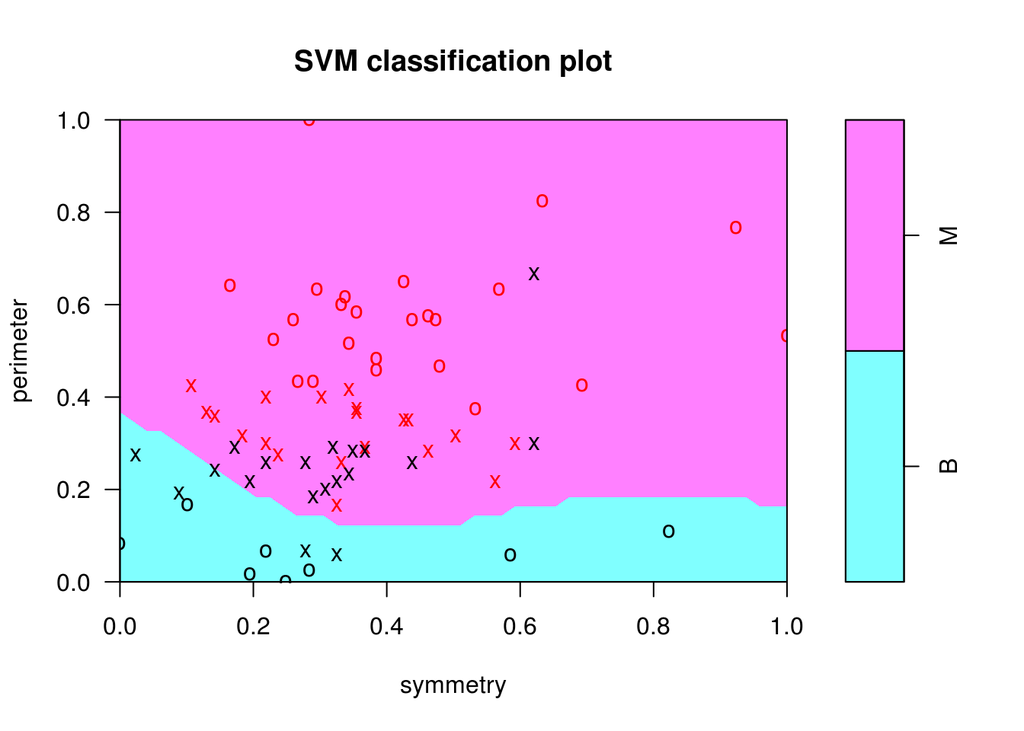

```r
plot(svm_model, data=data.main)
```

Результаты на обучающей

```r
svm.Pred<-predict(svm_model, data.main, probability=FALSE)
confusionMatrix(svm.Pred,data.main$diagnosis_result)
```

```
## Confusion Matrix and Statistics
##
##           Reference
## Prediction  B  M
##          B 12  0
##          M 15 44
##
##                Accuracy : 0.7887
##                  95% CI : (0.6756, 0.8767)
##     No Information Rate : 0.6197
##     P-Value [Acc > NIR] : 0.0017886
##
##                   Kappa : 0.4979
##  Mcnemar's Test P-Value : 0.0003006
##
##             Sensitivity : 0.4444
##             Specificity : 1.0000
##          Pos Pred Value : 1.0000
##          Neg Pred Value : 0.7458
##              Prevalence : 0.3803
##          Detection Rate : 0.1690
##    Detection Prevalence : 0.1690
##       Balanced Accuracy : 0.7222
##
##        'Positive' Class : B
##
```

и тестовой выборках

```r
svm.Pred<-predict(svm_model, data.test, probability=FALSE)
confusionMatrix(svm.Pred,data.test$diagnosis_result)
```

```
## Confusion Matrix and Statistics
##
##           Reference
## Prediction  B  M
##          B  4  0
##          M  7 18
##
##                Accuracy : 0.7586
##                  95% CI : (0.5646, 0.897)
##     No Information Rate : 0.6207
##     P-Value [Acc > NIR] : 0.08751
##
##                   Kappa : 0.415
##  Mcnemar's Test P-Value : 0.02334
##
##             Sensitivity : 0.3636
##             Specificity : 1.0000
##          Pos Pred Value : 1.0000
##          Neg Pred Value : 0.7200
##              Prevalence : 0.3793
##          Detection Rate : 0.1379
##    Detection Prevalence : 0.1379
##       Balanced Accuracy : 0.6818
##
##        'Positive' Class : B
##
```

Для полной картины (и для удобного использования кросс-валидации, например) посмотрим, как такую модель можно построить с помощью функций пакета `caret`. Напомним, что эти функции – обертки, они используют реализации из существующих пакетов. Например, SVM с линейным ядром из пакета `kernlab` можно построить, используя method = “svmLinear”. А с радиальным method = “svmRadial” (пакет `kernlab`), с полиномиальным method = “svmPoly” (пакет `kernlab`)

```r
library(kernlab)
svm_model0 <- caret::train(factor(diagnosis_result) ~ ., data=data.main, method = 'svmPoly')
svm_model0$finalModel
```

```
## Support Vector Machine object of class "ksvm"
##
## SV type: C-svc  (classification)
##  parameter : cost C = 1
##
## Polynomial kernel function.
##  Hyperparameters : degree =  2  scale =  0.1  offset =  1
##
## Number of Support Vectors : 40
##
## Objective Function Value : -33.3494
## Training error : 0.126761
```

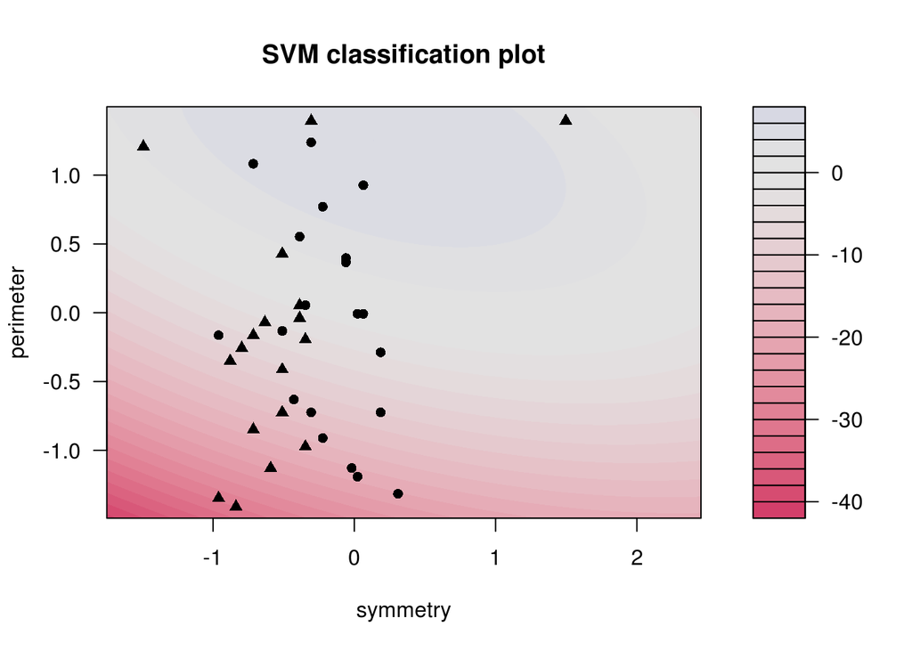

```r
plot(svm_model0$finalModel)
```

### Метод опорных векторов с радиальным ядром (Support Vector Machine with radial kernel)

```r
svm_model <- svm(diagnosis_result ~ ., data=data.main, kernel="radial")
summary(svm_model)
```

```
##
## Call:
## svm(formula = diagnosis_result ~ ., data = data.main, kernel = "radial")
##
##
## Parameters:
##    SVM-Type:  C-classification
##  SVM-Kernel:  radial
##        cost:  1
##       gamma:  0.5
##
## Number of Support Vectors:  38
##
##  ( 21 17 )
##
##
## Number of Classes:  2
##
## Levels:
##  B M
```

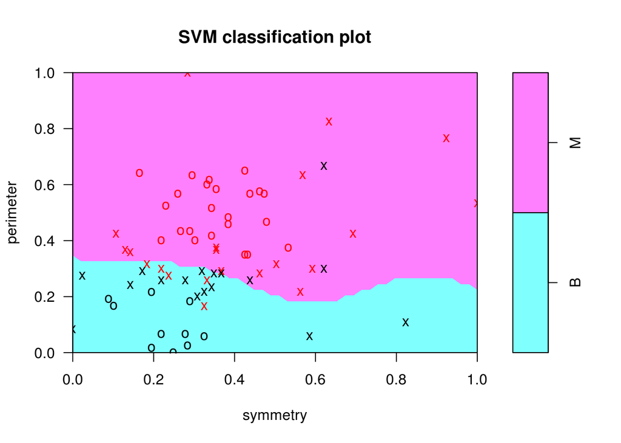

```r
plot(svm_model, data=data.main)
```

Результаты на обучающей

```r
svm.Pred<-predict(svm_model, data.main, probability=FALSE)
confusionMatrix(svm.Pred,data.main$diagnosis_result)
```

```
## Confusion Matrix and Statistics
##
##           Reference
## Prediction  B  M
##          B 22  4
##          M  5 40
##
##                Accuracy : 0.8732
##                  95% CI : (0.773, 0.9404)
##     No Information Rate : 0.6197
##     P-Value [Acc > NIR] : 2.087e-06
##
##                   Kappa : 0.7291
##  Mcnemar's Test P-Value : 1
##
##             Sensitivity : 0.8148
##             Specificity : 0.9091
##          Pos Pred Value : 0.8462
##          Neg Pred Value : 0.8889
##              Prevalence : 0.3803
##          Detection Rate : 0.3099
##    Detection Prevalence : 0.3662
##       Balanced Accuracy : 0.8620
##
##        'Positive' Class : B
##
```

и тестовой выборках

```r
svm.Pred<-predict(svm_model, data.test, probability=FALSE)
confusionMatrix(svm.Pred,data.test$diagnosis_result)
```

```
## Confusion Matrix and Statistics
##
##           Reference
## Prediction  B  M
##          B  8  2
##          M  3 16
##
##                Accuracy : 0.8276
##                  95% CI : (0.6423, 0.9415)
##     No Information Rate : 0.6207
##     P-Value [Acc > NIR] : 0.01422
##
##                   Kappa : 0.6272
##  Mcnemar's Test P-Value : 1.00000
##
##             Sensitivity : 0.7273
##             Specificity : 0.8889
##          Pos Pred Value : 0.8000
##          Neg Pred Value : 0.8421
##              Prevalence : 0.3793
##          Detection Rate : 0.2759
##    Detection Prevalence : 0.3448
##       Balanced Accuracy : 0.8081
##
##        'Positive' Class : B
##
```

### Метод опорных векторов с сигмоидным ядром (Support Vector Machine with sigmoid kernel)

```r
svm_model <- svm(diagnosis_result ~ ., data=data.main, kernel="sigmoid")
summary(svm_model)
```

```
##
## Call:
## svm(formula = diagnosis_result ~ ., data = data.main, kernel = "sigmoid")
##
##
## Parameters:
##    SVM-Type:  C-classification
##  SVM-Kernel:  sigmoid
##        cost:  1
##       gamma:  0.5
##      coef.0:  0
##
## Number of Support Vectors:  30
##
##  ( 15 15 )
##
##
## Number of Classes:  2
##
## Levels:
##  B M
```

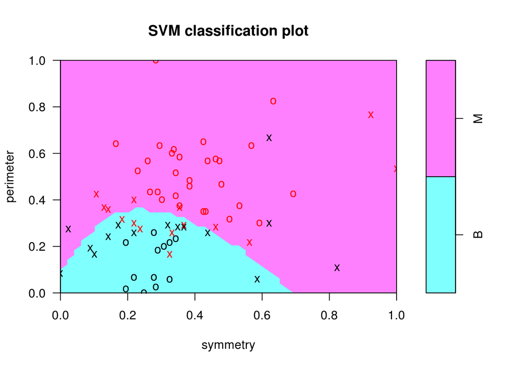

```r
plot(svm_model, data=data.main)
```

Результаты на обучающей

```r
svm.Pred<-predict(svm_model, data.main, probability=FALSE)
confusionMatrix(svm.Pred,data.main$diagnosis_result)
```

```
## Confusion Matrix and Statistics
##
##           Reference
## Prediction  B  M
##          B 22  6
##          M  5 38
##
##                Accuracy : 0.8451
##                  95% CI : (0.7397, 0.92)
##     No Information Rate : 0.6197
##     P-Value [Acc > NIR] : 2.919e-05
##
##                   Kappa : 0.6736
##  Mcnemar's Test P-Value : 1
##
##             Sensitivity : 0.8148
##             Specificity : 0.8636
##          Pos Pred Value : 0.7857
##          Neg Pred Value : 0.8837
##              Prevalence : 0.3803
##          Detection Rate : 0.3099
##    Detection Prevalence : 0.3944
##       Balanced Accuracy : 0.8392
##
##        'Positive' Class : B
##
```

и тестовой выборках

```r
svm.Pred<-predict(svm_model, data.test, probability=FALSE)
confusionMatrix(svm.Pred,data.test$diagnosis_result)
```

```
## Confusion Matrix and Statistics
##
##           Reference
## Prediction  B  M
##          B  6  2
##          M  5 16
##
##                Accuracy : 0.7586
##                  95% CI : (0.5646, 0.897)
##     No Information Rate : 0.6207
##     P-Value [Acc > NIR] : 0.08751
##
##                   Kappa : 0.4587
##  Mcnemar's Test P-Value : 0.44969
##
##             Sensitivity : 0.5455
##             Specificity : 0.8889
##          Pos Pred Value : 0.7500
##          Neg Pred Value : 0.7619
##              Prevalence : 0.3793
##          Detection Rate : 0.2069
##    Detection Prevalence : 0.2759
##       Balanced Accuracy : 0.7172
##
##        'Positive' Class : B
##
```

При выборе ядра мы определяем класс функций. Как выбрать ее конкретные параметры?

```r
svm_tune <- tune.svm(diagnosis_result ~ ., data=data.main, kernel="sigmoid",
                     cost=10^(-2:2), gamma=c(0.1,0.5,1,2), coef0 = -2:2)
print(svm_tune)
```

```
##
## Parameter tuning of 'svm':
##
## - sampling method: 10-fold cross validation
##
## - best parameters:
##  gamma coef0 cost
##    0.1     1   10
##
## - best performance: 0.1428571
```

Модель с новыми параметрами

```r
svm_model <- svm(diagnosis_result ~ ., data=data.main, kernel="sigmoid",
                 gamma = as.numeric(svm_tune$best.parameters["gamma"]),
                 cost = as.numeric(svm_tune$best.parameters["cost"]),
                 coef0 = as.numeric(svm_tune$best.parameters["coef0"]))
summary(svm_model)
```

```
##
## Call:
## svm(formula = diagnosis_result ~ ., data = data.main, kernel = "sigmoid",
##     gamma = as.numeric(svm_tune$best.parameters["gamma"]), cost = as.numeric(svm_tune$best.parameters["cost"]),
##     coef0 = as.numeric(svm_tune$best.parameters["coef0"]))
##
##
## Parameters:
##    SVM-Type:  C-classification
##  SVM-Kernel:  sigmoid
##        cost:  10
##       gamma:  0.1
##      coef.0:  1
##
## Number of Support Vectors:  31
##
##  ( 15 16 )
##
##
## Number of Classes:  2
##
## Levels:
##  B M
```

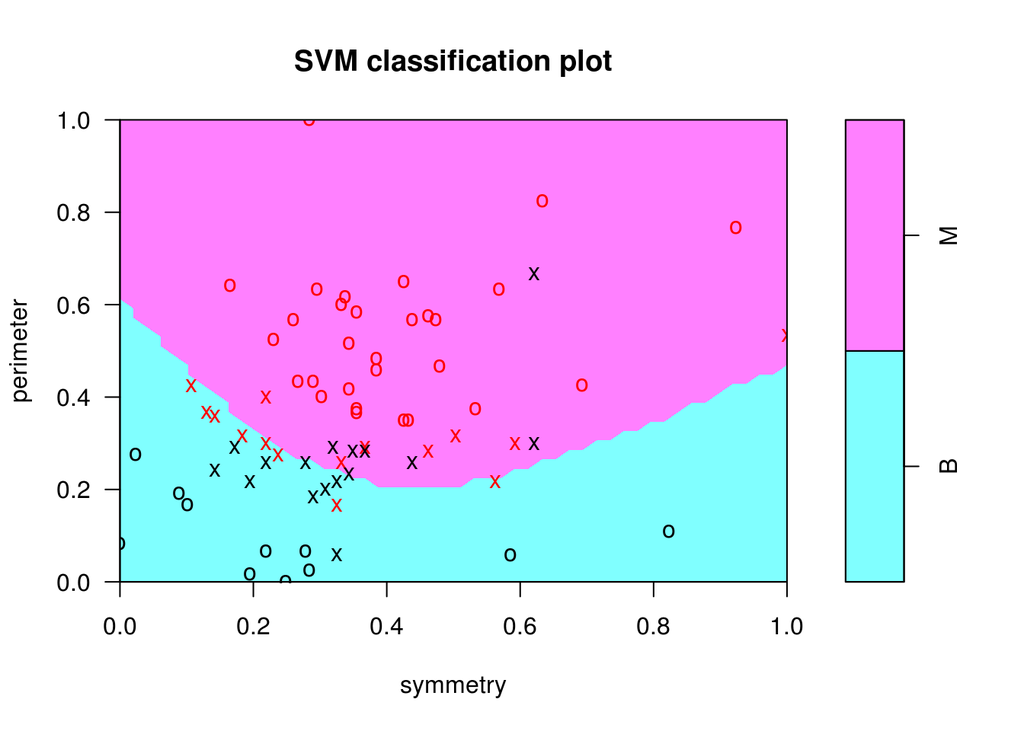

```r
plot(svm_model, data=data.main)
```

Результаты на обучающей

```r
svm.Pred<-predict(svm_model, data.main, probability=FALSE)
confusionMatrix(svm.Pred,data.main$diagnosis_result)
```

```
## Confusion Matrix and Statistics
##
##           Reference
## Prediction  B  M
##          B 19  8
##          M  8 36
##
##                Accuracy : 0.7746
##                  95% CI : (0.66, 0.8654)
##     No Information Rate : 0.6197
##     P-Value [Acc > NIR] : 0.004068
##
##                   Kappa : 0.5219
##  Mcnemar's Test P-Value : 1.000000
##
##             Sensitivity : 0.7037
##             Specificity : 0.8182
##          Pos Pred Value : 0.7037
##          Neg Pred Value : 0.8182
##              Prevalence : 0.3803
##          Detection Rate : 0.2676
##    Detection Prevalence : 0.3803
##       Balanced Accuracy : 0.7609
##
##        'Positive' Class : B
##
```

и тестовой выборках

```r
svm.Pred<-predict(svm_model, data.test, probability=FALSE)
confusionMatrix(svm.Pred,data.test$diagnosis_result)
```

```
## Confusion Matrix and Statistics
##
##           Reference
## Prediction  B  M
##          B  6  1
##          M  5 17
##
##                Accuracy : 0.7931
##                  95% CI : (0.6028, 0.9201)
##     No Information Rate : 0.6207
##     P-Value [Acc > NIR] : 0.03859
##
##                   Kappa : 0.5272
##  Mcnemar's Test P-Value : 0.22067
##
##             Sensitivity : 0.5455
##             Specificity : 0.9444
##          Pos Pred Value : 0.8571
##          Neg Pred Value : 0.7727
##              Prevalence : 0.3793
##          Detection Rate : 0.2069
##    Detection Prevalence : 0.2414
##       Balanced Accuracy : 0.7449
##
##        'Positive' Class : B
##
```

**Ваша очередь**:

- Улучшится ли точность, если добавить остальные предикторы?